# Data Wrangling

# R 語言與資料科學導論作業 (W5)

一般系 b96001001 未命名

## Data Analysis

### 請使用R的內建資料`esoph`當作練習用的資料。

#### 一、請先瞭解一下這個資料的內容（`help(esoph)`）。

- 請列出這筆資料的簡單描述統計。如果該筆變項是類別變項，請描述其次數分配；若該筆變項是連續變項，請至少呈現中數和平均數。
- 請找出這個資料集共有幾列資料。

```r
# your code goes here
summary(esoph)
```

```
##    agegp          alcgp         tobgp        ncases         ncontrols
##  25-34:15   0-39g/day:23   0-9g/day:24   Min.   : 0.000   Min.   : 1.00
##  35-44:15   40-79    :23   10-19   :24   1st Qu.: 0.000   1st Qu.: 3.00
##  45-54:16   80-119   :21   20-29   :20   Median : 1.000   Median : 6.00
##  55-64:16   120+     :21   30+     :20   Mean   : 2.273   Mean   :11.08
##  65-74:15                                3rd Qu.: 4.000   3rd Qu.:14.00
##  75+  :11                                Max.   :17.000   Max.   :60.00
```

```r
names(esoph)
```

```
## [1] "agegp"     "alcgp"     "tobgp"     "ncases"    "ncontrols"
```

```r
dim(esoph)
```

```
## [1] 88  5
```

#### 二、資料作圖

- 請對此資料集做一張圖，任何圖（散佈圖、直方圖、或課堂上看到的矩陣散佈圖）都可以。

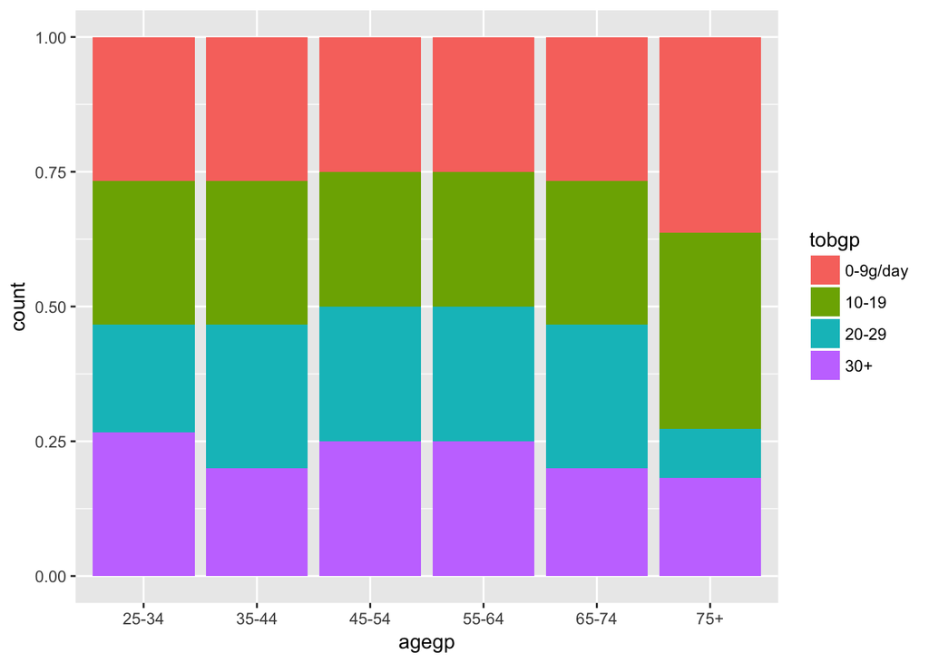

```r
# your code goes here
library(ggplot2)

ggplot(esoph,aes(agegp,fill=tobgp))+geom_bar(position = "fill")
```

#### 三、請做出一個各年齡組的摘要表。

- 這張摘要表應有6列，每列分別是一個年齡組。每列資料除了有年齡組(agegp)這個分組變項外，還需有sum_ncases變項，代表在各年齡組中，所有ncases的總和；以及sum_ncontrols，代表在各年齡組中，所有ncontrols的總和。

```r
# your code goes here
library(plyr)

ddply(esoph,.(agegp),summarize,sum_ncases=sum(ncases),sum_ncontrols=sum(ncontrols))
```

```
##   agegp sum_ncases sum_ncontrols
## 1 25-34          1           116
## 2 35-44          9           199
## 3 45-54         46           213
## 4 55-64         76           242
## 5 65-74         55           161
## 6   75+         13            44
```

#### 四、不同酒精使用程度的摘要表。

- 假設現在僅關心是25-34和45-54兩個年齡組，他們在不同酒精使用程度中的個案數和控制組數。
- 這張表格應該有8列，並且共有4個變項：前兩個變項是年齡組與酒精使用程度。後兩個變項是所有在該年齡組和酒精使用程度中，其個案數和控制組數的總和。

```r
# your code goes here
library(plyr)

ddply(esoph,.(agegp=c("25-34","45-54"),alcgp),summarize,sum_ncases=sum(ncases),sum_ncontrols=sum(ncontrols))
```

```
##   agegp     alcgp sum_ncases sum_ncontrols
## 1 25-34 0-39g/day         16           246
## 2  <NA>     40-79         51           223
## 3  <NA>    80-119         22            70
## 4  <NA>      120+         18            31
## 5 45-54 0-39g/day         13           169
## 6  <NA>     40-79         24           132
## 7  <NA>    80-119         29            68
## 8  <NA>      120+         27            36
```

## 進階選答題

[台北YouBike 開放資料](https://goo.gl/KLxuhf)是一個很常在資料科學專案應用或教學的例子。這個資料就在我們身邊，我們都接觸過他，甚至才剛剛貢獻過一點資料。這個作業請你試著接觸YouBike資料，看看裡面有什麼訊息。

### A. 把YouBike資料轉為data.frame

請你先到[台北YouBike 開放資料](https://goo.gl/KLxuhf)看一下資料描述。其中提到現在的介接網址是http://data.taipei/youbike。你可以直接在R裡面把這個檔案下載下來；或者手動把它下載下來後，把JSON格式換成R的data.frame。

```r
# your code goes here.
# please display the data with head() in the last line

library(readr)
demo_data_path <- "youbike_demo_data.csv"
if(file.exists(demo_data_path)){
    bike <- read_csv(demo_data_path, locale=locale(encoding="UTF-8"))
} else {
    warning(paste0("Cannot find ", demo_data_path))
}
head(bike)
```

```
## # A tibble: 6 x 11
##     sno                       sna   tot   sbi  sarea                mday
##   <int>                     <chr> <int> <int>  <chr>              <dttm>
## 1     1     捷運市政府站(3號出口)   180   139 信義區 2017-10-09 03:19:35
## 2     2 捷運國父紀念館站(2號出口)    48    31 大安區 2017-10-09 03:19:31
## 3     3                台北市政府    40    13 信義區 2017-10-09 03:19:39
## 4     4                  市民廣場    60    34 信義區 2017-10-09 03:19:40
## 5     5                  興雅國中    60    36 信義區 2017-10-09 03:19:39
## 6     6                  世貿二館    80     0 信義區 2017-09-08 00:43:45
## # ... with 5 more variables: lat <dbl>, lng <dbl>, ar <chr>, bemp <int>,
## #   act <int>
```

```r
# your code goes here
library(dplyr)
library(plyr)

look <- ddply(bike,.(sarea),summarize,tot=mean(tot),sbi=sum(sbi),bemp=sum(bemp))
look %>% arrange(desc(bemp))
```

```
##     sarea      tot sbi bemp
## 1  大安區 43.04348 790 1122
## 2  中山區 40.48889 894  908
## 3  信義區 48.40000 807  791
## 4  士林區 39.45455 521  765
## 5  內湖區 38.16216 702  694
## 6  中正區 43.23529 703  694
## 7  北投區 43.50000 523  686
## 8  松山區 38.51613 524  619
## 9  萬華區 38.72727 278  560
## 10 文山區 38.91667 401  517
## 11 南港區 36.63636 388  411
## 12 大同區 37.14286 331  370
```

### C. 請篩選出空位率最高的5％站點，並且按照他們的空位率（從大到小）排序。

```r
# your code goes here
v<-bike$bemp
ccc<-v[{q<-rank(v)/length(v);q>=0.95}]

bike_bemp<-bike[bike$bemp %in% ccc,]

 bike_bemp %>%
   select(sna,bemp) %>%
   arrange(desc(bemp))
```

```
## # A tibble: 21 x 2
##                      sna  bemp
##                    <chr> <int>
##  1      羅斯福新生南路口    76
##  2              興安華城    65
##  3            捷運明德站    56
##  4                三張犁    55
##  5     信義廣場(台北101)    54
##  6          基隆長興路口    54
##  7              光華商場    51
##  8          臺北市立大學    48
##  9   捷運石牌站(2號出口)    46
## 10 捷運唭哩岸站(2號出口)    46
## # ... with 11 more rows
```

### D. 請把站點的位置畫在一張地圖上，並且同時呈現每個站點的空位率（或可使用率）。

[figure not shown]

```r
# your code goes here
library(ggmap)
library(ggplot2)
library(wesanderson)

map <- get_map(location = "Taipei",zoom =  12 ,language = "zh-TW")
ggmap(map)+geom_point(aes(x = lng ,y = lat ,color = bemp),data = bike)+scale_color_gradient(low="blue", high="red")
```